# Practical Machine Learning Course Project

submitted by Steve Myles

26 December 2015

### Introduction

In [a study](http://groupware.les.inf.puc-rio.br/har), six participants were asked to perform dumbbell lifts correctly and incorrectly in five different ways. Data were gathered from accelerometers on the belt, forearm, arm, and dumbbell of each participant. The test subjects were all males aged 20-28 years and the dumbbells were light, 1.25kg.

This report describes a method for predicting the way in which the participants did the exercise (the `classe` variable in the data). Class A indicates the correct execution of the exercise while the other four values of this variable represent common mistakes.

To begin the analysis and prediction, relevant packages were installed. Then, the data were downloaded and an exploratory analysis was performed. Finally, the machine learning algorithm was created and testing on a training set of data. The prediction model was also used to predict 20 test cases.

### Getting Data and Loading Packages

The training and test sets of data were first downloaded (using [this function](http://projects.mylesandmyles.info/R-functions-and-such/download_and_unzip/download_and_unzip.html)) and assigned to dataframes (the training data set was assigned to `train` and the testing data set was assigned to `test`). Packages required for this analysis (`caret`, `doParallel`, and `randomForest`) were loaded into memory using [this function](http://projects.mylesandmyles.info/R-functions-and-such/pkgInst/pkgInst.html).

```r
## download the data if it is not currently in the working directory
downLoad <- function(dir = "data", url, file) {
    ## check if the expected directory exists in the working directory.
    dir <- paste("./", dir, sep = "")
    if (!file.exists(dir)) {
        ## if not, check whether the expected file exists in the working
        ## directory
        if (!file.exists(file)) {
            ## if not, try to download it
            download.file(url, file, mode="wb")
        }
    }
}

## download the training data and assign it to a dataframe called "train," converting
## blank observations to NA
downLoad(url = "https://d396qusza40orc.cloudfront.net/predmachlearn/pml-training.csv")
train <- read.csv("data/pml-training.csv", na.strings=c("","NA"))

## download the testing data and assign it to a dataframe called "test"
downLoad(url = "https://d396qusza40orc.cloudfront.net/predmachlearn/pml-testing.csv")
test <- read.csv("data/pml-testing.csv")

## load relevant packages into the R environment, installing them if necessary
pkgInst <- function(x) {
    for (i in x) {
        ## "require" returns TRUE invisibly if it was able to load package
        if (!require(i, character.only = TRUE)) {
            ## if package was not able to be loaded, install it
            install.packages(i, dependencies = TRUE,
                             repos="http://cran.r-project.org/")
            ## load package after installing
            require (i, character.only = TRUE)
        }
    }
}

## assign names of required packages to "pkgs"
pkgs <- c("R2HTML", "caret", "doParallel", "randomForest")

## load/install packages
pkgInst(pkgs)
```

### Exploratory Data Analysis

```r
## assign the summary table of the training data set to the variable summ
summ <- summary(train)

## use the R2HTML package's "HTML" function to write the output to an html file
HTML(summ, file="summary.html")
```

For purposes of this exercise, the row number (variable `X`) is irrelevant and is thus dropped from the analysis. Also, several columns in the dataframe have 19,216 observations with value of NA (e.g., `max_roll_belt`). These are removed from consideration as having complete data sets is likely to increase prediction accuracy.

```r
## remove the column with the row number
train$X <- NULL

## remove the columns with 19,216 NA observations
train <- train[,colSums(is.na(train)) < 19216]
```

The remaining fifty-eight (58) variables were used as predictors (there are (fifty-nine (59) remaining columns including `classe`).

A histogram showing the frequency of the values of `classe` was created to see if there is a large skew in the data toward one of the possible ways of performing the exercise. The frequency histogram was created using the method described in [this Stack Overflow answer](http://stackoverflow.com/a/9122859)

```r
## create a variable to represent the x-axis as "classe" is a factor and
## histograms can only be drawn for numeric data
classnum <- as.numeric(train$classe)

## create the histogram and change its density to percentages
h <- hist(classnum)
h$density <- h$counts / sum(h$counts) * 100
```

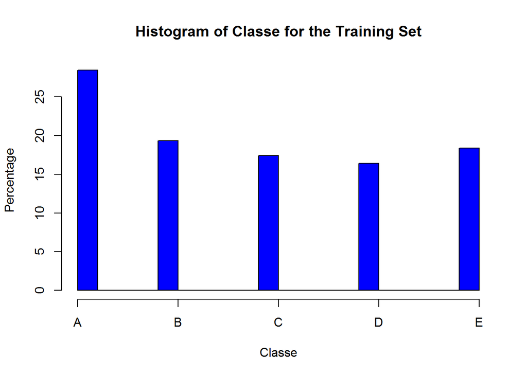

```r
## plot the histogram, leaving the x-axis blank
plot(h, freq = F, main = "Histogram of Classe for the Training Set", ylab =
         "Percentage", xlab="Classe", xaxt="n", col="blue")

## add the axis
axis(1,at=1:5,labels = c("A","B","C","D","E"))
```

### Prediction Algorithm

```r
## use two cores
registerDoParallel(cores=2)

## set trainControl parameters
ctrl <- trainControl(method = "cv", repeats = 10)

## fit the model
modelFit <- train(classe ~ ., data = train, method = "rf", trControl = ctrl,
                  preProcess = "pca")
```

### In-Sample Error: Accuracy with Training Set

The prediction algorithm was then used to predict the training data set in order to determine its accuracy.

```r
## first, display the model's output
modelFit
```

```
## Random Forest
##
## 19622 samples
##    58 predictor
##     5 classes: 'A', 'B', 'C', 'D', 'E'
##
## Pre-processing: principal component signal extraction (80), centered
##  (80), scaled (80)
## Resampling: Cross-Validated (10 fold)
## Summary of sample sizes: 17659, 17660, 17662, 17658, 17659, 17661, ...
## Resampling results across tuning parameters:
##
##   mtry  Accuracy   Kappa      Accuracy SD  Kappa SD
##    2    0.9867494  0.9832400  0.001982079  0.002506222
##   41    0.9815513  0.9766656  0.002694792  0.003407737
##   80    0.9805827  0.9754408  0.002756402  0.003486487
##
## Accuracy was used to select the optimal model using  the largest value.
## The final value used for the model was mtry = 2.
```

```r
## then predict the training set
predTrain <- predict(modelFit, train)

## then display the accuracy of the model
table(predTrain,train$classe)
```

```
##
## predTrain    A    B    C    D    E
##         A 5580    0    0    0    0
##         B    0 3797    0    0    0
##         C    0    0 3422    0    0
##         D    0    0    0 3216    0
##         E    0    0    0    0 3607
```

From the above table, the prediction algorithm’s in-sample error (the accuracy of its predictions for the training set) is 100%. This follows as the training set was used to create the prediction algorithm, though this accuracy is very high even for in-sample error. Of course, the actual predictive accuracy of the algorithm is the out of sample error, which was next calculated by predicting the values of the test set. This must be less than or equal to the in-sample error (regardless of the in-sample error’s actual value).

### Out of Sample Error: Accuracy with Testing Set

Per the assignment, the prediction algorithm created above is applied to the twenty (20) cases in the testing data set. For each test case, a text file is created with a single capital letter (A, B, C, D, or E) corresponding to the prediction for the corresponding problem in the test data set. These files were then manually submitted to Coursera for grading.

```r
## predict the testing set and store the results in a character vector
predTest <- as.character(predict(modelFit, test))

## display the predictions
predTest
```

```
##  [1] "B" "A" "A" "A" "A" "E" "D" "B" "A" "A" "B" "C" "B" "A" "E" "E" "A"
## [18] "B" "B" "B"
```

```r
## create a directory called "test_output," suppressing warnings if the
## directory already exists
dir.create(file.path("test_output"), showWarnings = FALSE)

## create a function to write the files to be submitted
pml_write_files = function(x){
    n = length(x)
    for(i in 1:n){
        filename = paste0("test_output/problem_id_", i, ".txt")
        write.table(x[i], file = filename, quote = FALSE, row.names = FALSE,
                    col.names=FALSE)
    }
}

## then create the files, one for each prediction
pml_write_files(predTest)
```

According to the “Prediction Assignment Submission” on Coursera, the algorithm described above accurately predicted nineteen (19) of the twenty (20) test cases, so its out of sample accuracy (accuracy with the test data) was 95% – only test problem 3 was incorrectly predicted. This level of accuracy makes sense due to out of sample error necessarily being less than or equal to in-sample error. Due to the small sample size of the test data set, it is possible that the algorithm would not perform as well for a larger data set.

### Notes

- The data set used is from [here](http://groupware.les.inf.puc-rio.br/har).
- This report was written in [R Markdown](http://rmarkdown.rstudio.com/) and converted to html via [knitr](http://knitr.com/).
- The domain http://projects.mylesandmyles.info/ is a [custom domain](https://help.github.com/articles/setting-up-a-custom-domain-with-github-pages/) for http://scumdogsteev.github.io/. The URL for this page is either http://projects.mylesandmyles.info/practicalmachinelearning/ or http://scumdogsteev.github.io/practicalmachinelearning/.
  - The repo for this report is located [here](https://github.com/scumdogsteev/practicalmachinelearning).
  - For the source .Rmd document for this page, please [click here](https://github.com/scumdogsteev/practicalmachinelearning/blob/gh-pages/index.Rmd).

### Citations

- Liaw, A. and M. Wiener (2002). Classification and Regression by randomForest. *R News* Vol. 2 N. 3, Vienna, Austria.
- Lecoutre, Eric (2003). The R2HTML Package. *R News*, Vol 3 N. 3, Vienna, Austria.
- Velloso, E., Bulling, A., Gellersen, H., Ugulino, W., Fuks, H. (2013). [Qualitative Activity Recognition of Weight Lifting Exercises](http://groupware.les.inf.puc-rio.br/work.jsf?p1=11201).  
  *Proceedings of 4th International Conference in Cooperation with SIGCHI (Augmented Human ’13)*, ACM SIGCHI, Stuttgart, Germany.